# PPA - Lucas Guaragna

# Define (D)

## Carregando os dados

```r
library(readxl)
dados <- read_xlsx(path = "Dados_Define.xlsx")
listaNS <- as.list(dados["NS atendimento"])
```

## Analisando os dados

**Média, Mediana, Mínimo, máximo**:

```r
summary(dados["NS atendimento"])
```

```
##  NS atendimento
##  Min.   :62.72
##  1st Qu.:66.92
##  Median :70.61
##  Mean   :71.42
##  3rd Qu.:76.42
##  Max.   :80.80
```

**Desvio padrão** dos dados:

```r
sd(dados$`NS atendimento`)
```

```
## [1] 5.769514
```

- Valor mais recente do indicador: 68.0

### Teste de Normalidade

1. Análise de densidade:

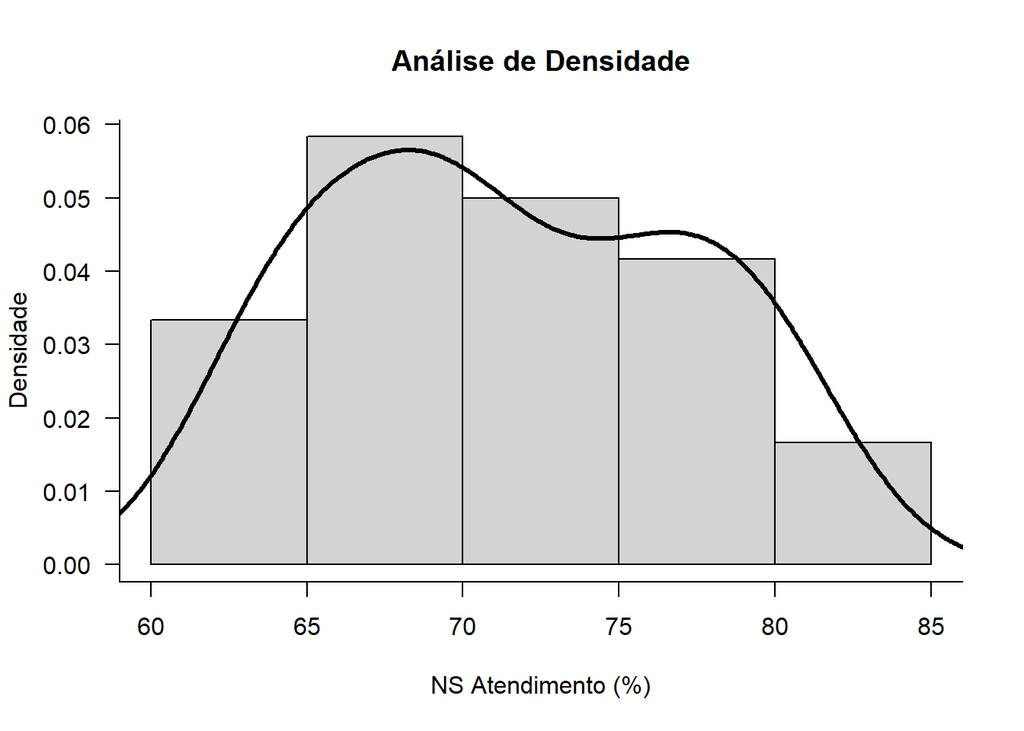

```r
hist(dados$`NS atendimento`,
     main = "Análise de Densidade",
     xlab = "NS Atendimento (%)",
     ylab = "Densidade",
     prob = T,
     las = 1)
lines(density(dados$`NS atendimento`), lwd = 3)
box(bty = "l")
```

2. Análise de frequência (Histograma)

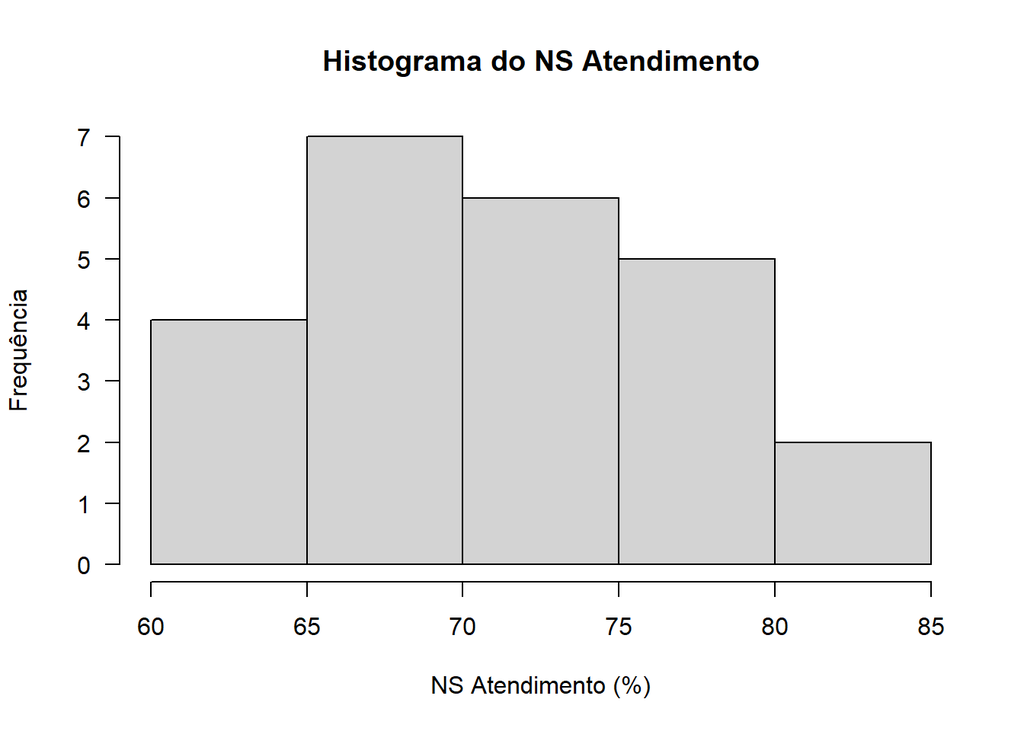

```r
hist(dados$`NS atendimento`,
     main = "Histograma do NS Atendimento",
     xlab = "NS Atendimento (%)",
     ylab = "Frequência",
     prob = F,
     las = 1)
```

A maior frequência de NS Atendimento se encontra entre 65 <= NS Atendimento <= 75 e a menor em 80 <= NS Atendimento <= 85.

3. Gráfico de Normalidade

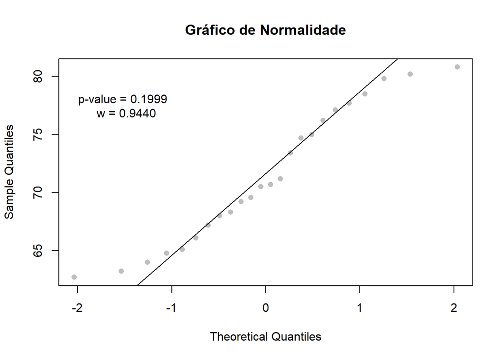

```r
# Teste de Normalidade
result <- shapiro.test(dados$`NS atendimento`)

#plotando o gráfico de normalidade
qqnorm(dados$`NS atendimento`,
       col = 'gray',
       pch = 16,
       main = NULL)
qqline(dados$`NS atendimento`)
title("Gráfico de Normalidade")

text(x = -1.5,
     y = 77.5,
     labels = sprintf("p-value = %.4f \n w = %.4f",
                      result$p.value,
                      result$statistic))
```

Como **p-value > 0.05**, os dados **são normais**.

### Gráfico de Séries Temporais

```r
lm(dados$`NS atendimento` ~ dados$Mês)
```

```
##
## Call:
## lm(formula = dados$`NS atendimento` ~ dados$Mês)
##
## Coefficients:
## (Intercept)    dados$Mês
##     79.3539      -0.6345
```

```r
# ypretido <- predict(modelo_linear)
```

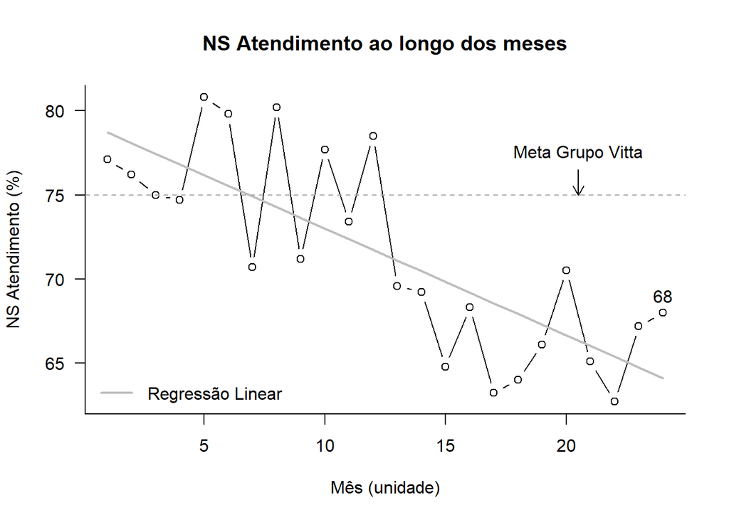

```r
# Plotando o gráfico na cor preta, sem a caixa ao seu redor, Definindo o nome dos eixos
plot(dados, type = "b", main = "NS Atendimento ao longo dos meses", col = "black", bty="n", xlab="Mês (unidade)", ylab="NS Atendimento (%)", xaxt = "n", yaxt = "n")

# Adicionando a regressão linear ao gráfico
lines(x = dados$Mês, y = predict(lm(dados$`NS atendimento` ~ dados$Mês)), col = "gray", lty = 1, lwd = 2)

# Definindo o redor do gráfico (em formato de L)
box(bty = "l")

# Definindo as posições dos elementos dos eixos
axis(side = 1, las = 1)
axis(side = 2, las = 1)

# Definindo a legenda da regressão
legend(x = "bottomleft",
       legend = "Regressão Linear",
       lty = 1,
       lwd = 2,
       bty = "n",
       col = "gray")

# Inserindo a linha da meta, a seta e o texto
abline(h = 75,
       lty = 2,
       col= "darkgray")
arrows(x0 = 20.5, y0 = 76.5,
       x1 = 20.5, y1 = 75,
       length = 0.1)
text(x = 20.5, y = 77.5,
     labels = "Meta Grupo Vitta")
text(x = 24, y = 69, labels = "68")
```

Existe um padrão de comportamento: linear

### Boxplot

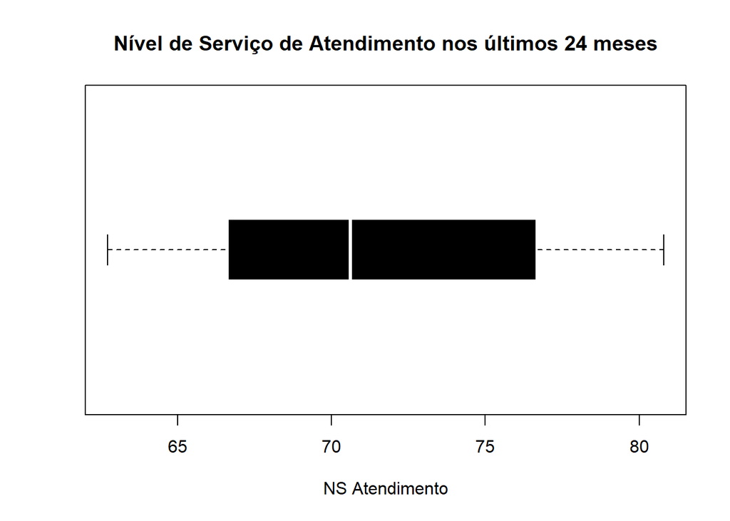

```r
bp <- boxplot(dados["NS atendimento"],
        main = "Nível de Serviço de Atendimento nos últimos 24 meses",
        bty = "n",
        xlab = "NS Atendimento",
        horizontal = T,
        border = "white",
        whiskcol = "black",
        staplecol = "black",
        outcol = "black",
        col = "black",
        outpch = 19,
        boxwex = 0.4,
        range = 0)
```

Limite inferior, Primeiro Quartil, Mediana/Segundo Quartil, Terceiro Quartil e Limite superior:

```r
bp$stats
```

```
##          [,1]
## [1,] 62.72265
## [2,] 66.64654
## [3,] 70.61281
## [4,] 76.65000
## [5,] 80.80000
```

Ao analisar a faixa entre o limite inferior e o primeiro quartil, observamos os piores valores já atingidos (62.72 - 66.65), representando 25% dos dados. Com o mesmo raciocínio, podemos analisar os valores entre o terceiro quartil e o limite superior (76.65 - 80.80), e verificar os melhores valores do indicador NS atendimento, representando, também, 25% dos dados.

## Definindo a meta do projeto

Considerando o valor do último mês do indicador NS Atendimento (68%), e o seu valor ideal (90%), existe, portanto, uma lacuna de 22%. Como uma meta deve ser estipulada em, no mínimo, 50% da lacuna (11%, no caso), temos que o valor de meta do indicador deve ser de, no mínimo **79%** em **6 meses de projeto** (*de 05/06/2023 a 05/12/2023*).

**Obs:** O ganho do projeto não será apenas financeiro: o aumento do NS Atendimento gera um melhor fluxo do cliente, aumentando a satisfação do cliente que, por sua vez, pode aumentar a demanda do atendimento e a fidalidade dos clientes do Grupo Vitta.